# Replication of “Anti-Immigrant Rhetoric and ICE Reporting Interest: Evidence from a Large-Scale Study of Web Search Data” paper

Ubaydul Sami and Buka Dikeocha

2024-06-24

```r
library(scales)
library(tidyverse)
library(knitr)
library(dplyr)
library(modelr)
library(scales)
library(readr)
```

```r
google_term_data <- read.csv('from_google_trends/google_3_terms_trend_data_04_20.csv', header = TRUE, sep= ",", skip = 2, col.names = c('ymd', 'immigr_report', 'immigr_crime', 'immigr_welfare'))

head(google_term_data)
```

```
##       ymd immigr_report immigr_crime immigr_welfare
## 1 2004-01             0            0              0
## 2 2004-02            36            0              0
## 3 2004-03             0            0              0
## 4 2004-04            48            0             34
## 5 2004-05            66            0              0
## 6 2004-06            35            0              0
```

# Figure 4 from paper

```r
google_term_data <-
  google_term_data |>
  mutate(ymd = as.Date(paste0(ymd, "-01")))|>
  mutate(year = year(ymd), month = month(ymd)) |>
  mutate(president = ifelse(year<=2008, "bush",
                      ifelse(year>2008 & year <= 2016, "obama", "trump")))
```

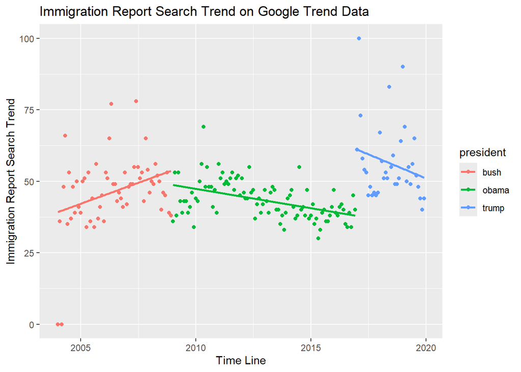

```r
google_term_data |>
  ggplot(aes(x = ymd, y= immigr_report, colour = president)) +
  geom_point() +
  geom_smooth(method = "lm", se = FALSE) +
  xlab("Time Line") +
  ylab("Immigration Report Search Trend") +
  ggtitle("Immigration Report Search Trend on Google Trend Data")
```

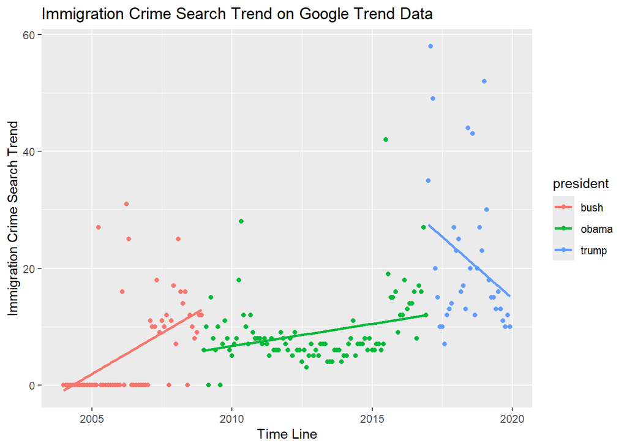

```r
google_term_data |>
  ggplot(aes(x = ymd, y= immigr_crime, colour = president)) +
  geom_point() +
  geom_smooth(method = "lm", se = FALSE) +
  xlab("Time Line") +
  ylab("Immigration Crime Search Trend") +
  ggtitle("Immigration Crime Search Trend on Google Trend Data")
```

[figure not shown]

```r
google_term_data |>
  ggplot(aes(x = ymd, y= immigr_welfare, colour = president)) +
  geom_point() +
  geom_smooth(method = "lm", se = FALSE) +
  xlab("Time Line") +
  ylab("Immigration Welfare Search Trend") +
  ggtitle("Immigration Welfare Search Trend on Google Trend Data")
```

# Table 3 of the paper

```r
library(stargazer)
library(fastDummies)
google_term_data <-
  google_term_data |>
  mutate(president = as.factor(president),
         president = relevel(president, ref = "obama"))

google_term_data_dummies <- dummy_cols(google_term_data, select_columns = "president", remove_first_dummy = FALSE)

head(google_term_data_dummies)
```

```
##          ymd immigr_report immigr_crime immigr_welfare year month president
## 1 2004-01-01             0            0              0 2004     1      bush
## 2 2004-02-01            36            0              0 2004     2      bush
## 3 2004-03-01             0            0              0 2004     3      bush
## 4 2004-04-01            48            0             34 2004     4      bush
## 5 2004-05-01            66            0              0 2004     5      bush
## 6 2004-06-01            35            0              0 2004     6      bush
##   president_obama president_bush president_trump
## 1               0              1               0
## 2               0              1               0
## 3               0              1               0
## 4               0              1               0
## 5               0              1               0
## 6               0              1               0
```

```r
model_crime <- lm(immigr_crime ~ (ymd + president_bush + president_trump + president_obama), data = google_term_data_dummies)
model_welfare <- lm(immigr_welfare ~ (ymd + president_bush + president_trump + president_obama), data = google_term_data_dummies)
model_report <- lm(immigr_report ~ (ymd + president_bush + president_trump + president_obama ), data = google_term_data_dummies)
```

```r
model_crime2 <- lm(immigr_crime ~ ymd + president, data = google_term_data_dummies)
model_welfare2 <- lm(immigr_welfare ~ (ymd + president), data = google_term_data_dummies)
model_report2 <- lm(immigr_report ~ (ymd + president), data = google_term_data_dummies)
```

# with dummies

```r
stargazer(model_crime, model_welfare, model_report,
          title = "Table 3 OLS",
          dep.var.labels = c("Crime", "Welfare", "Report"),

          # out = "table3_ols.html", # Save to HTML file
          type = "text", # You can also use "html" or "latex"
          intercept.bottom = FALSE,
          omit.stat = c("ser", "adj.rsq", "f", "aic"),
          notes = "Note: ∗p<0.1; ∗∗p<0.05; ∗∗∗p<0.01" )
```

```
##
## Table 3 OLS
## ===================================================
##                         Dependent variable:
##                 -----------------------------------
##                     Crime      Welfare     Report
##                      (1)         (2)        (3)
## ---------------------------------------------------
## Constant          -31.598**    -10.665   70.043***
##                   (13.669)     (11.714)   (17.008)
##
## ymd               0.003***      0.001*     -0.002
##                    (0.001)     (0.001)    (0.001)
##
## president_bush      3.179       1.682      -0.977
##                    (2.465)     (2.112)    (3.067)
##
## president_trump   7.206***     4.744**   16.289***
##                    (2.368)     (2.030)    (2.947)
##
## president_obama
##
##
## ---------------------------------------------------
## Observations         192         192        192
## R2                  0.332       0.196      0.191
## ===================================================
## Note:                   *p<0.1; **p<0.05; ***p<0.01
##                   Note: ∗p<0.1; ∗∗p<0.05; ∗∗∗p<0.01
```

# with factored variable

```r
stargazer(model_crime2, model_welfare2, model_report2,
          title = "Table 3 OLS",
          dep.var.labels = c("Crime", "Welfare", "Report"),

          out = "table3_ols.html", # Save to HTML file
          type = "text", # You can also use "html" or "latex"
          intercept.bottom = FALSE,
          omit.stat = c("ser", "adj.rsq", "f", "aic"),
          notes = "Note: ∗p<0.1; ∗∗p<0.05; ∗∗∗p<0.01" )
```

```
##
## Table 3 OLS
## ==================================================
##                        Dependent variable:
##                -----------------------------------
##                    Crime      Welfare     Report
##                     (1)         (2)        (3)
## --------------------------------------------------
## Constant         -31.598**    -10.665   70.043***
##                  (13.669)     (11.714)   (17.008)
##
## ymd              0.003***      0.001*     -0.002
##                   (0.001)     (0.001)    (0.001)
##
## presidentbush      3.179       1.682      -0.977
##                   (2.465)     (2.112)    (3.067)
##
## presidenttrump   7.206***     4.744**   16.289***
##                   (2.368)     (2.030)    (2.947)
##
## --------------------------------------------------
## Observations        192         192        192
## R2                 0.332       0.196      0.191
## ==================================================
## Note:                  *p<0.1; **p<0.05; ***p<0.01
##                  Note: ∗p<0.1; ∗∗p<0.05; ∗∗∗p<0.01
```

# Figure 2 from paper

```r
library(stm)
load("from_replication_files/topic_model_lite.Rdata")
# document_topics <- make.dt(immigrFit, meta = out$meta)
# topic_terms <- t(exp(immigrFit$beta$logbeta[[1]]))
# rownames(topic_terms) <- out$vocab
# colnames(topic_terms) <- sprintf("Topic%d", 1:ncol(topic_terms))
```

```r
document_topics_figure <- document_topics |>
  mutate(date = as.Date(date),
         year_month = ym(format(date, "%Y-%m")))
head(document_topics_figure)
```

```
##    docnum      Topic1      Topic2      Topic3     Topic4      Topic5     Topic6
##     <int>       <num>       <num>       <num>      <num>       <num>      <num>
## 1:      1 0.004481022 0.009960933 0.004461316 0.01173189 0.055799780 0.11100898
## 2:      2 0.007721907 0.010274636 0.007847635 0.02223299 0.012992140 0.04594693
## 3:      3 0.001990162 0.036386592 0.001962287 0.03997450 0.015489060 0.02125399
## 4:      4 0.066536793 0.007539572 0.014041768 0.02412229 0.054856524 0.01472651
## 5:      5 0.007608635 0.006301671 0.008562301 0.03237121 0.005584864 0.26136304
## 6:      6 0.001472374 0.005644046 0.001495451 0.01790099 0.007050577 0.01825270
##         Topic7     Topic8     Topic9     Topic10     Topic11    Topic12
##          <num>      <num>      <num>       <num>       <num>      <num>
## 1: 0.006210360 0.03328737 0.03705146 0.009866943 0.004249936 0.03460265
## 2: 0.009107538 0.02681331 0.04657247 0.016150845 0.015244264 0.15595228
## 3: 0.005533472 0.01596025 0.04617686 0.013243828 0.030639023 0.07490007
## 4: 0.007204676 0.02533136 0.06158577 0.019073330 0.008334470 0.06095308
## 5: 0.008460921 0.07231750 0.09063208 0.012023576 0.006875597 0.03770051
```

[output cut: 65 more lines]

```r
# document_topics_figure |>
#   select(year_month, channel,duration, time) |>
#   group_by(year_month, channel, time) |>
#   summarise(air_count= sum(duration)) |>
#   ggplot(aes(x = year_month, y = air_count, colour = channel)) +
#   geom_point()
```

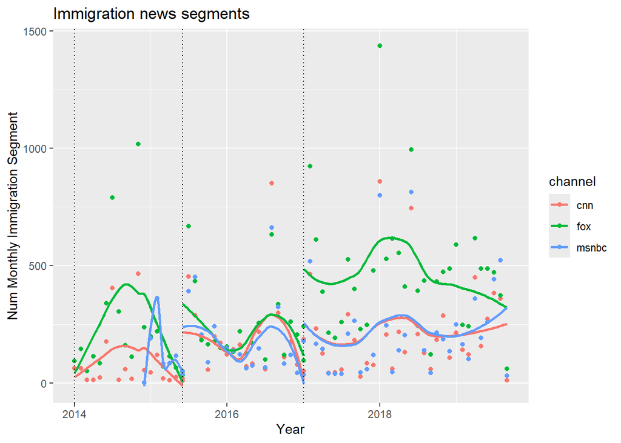

```r
time_lines <- document_topics_figure |>
  select(time, year_month) |>
  group_by(time) |>
  summarise(year_month = min(year_month))


document_topics_figure |>
  select(year_month, channel,duration, time) |>
  group_by(year_month, channel, time) |>
  summarise(air_count= sum(duration)) |>
  ungroup() |>
  group_by(channel, time) |>
  ggplot(aes(x = year_month, y = air_count, color = channel, group = interaction(channel, time))) +
  geom_point() + geom_smooth( se=FALSE) +
  geom_vline(data = time_lines, aes(xintercept = as.numeric(year_month)), linetype = "dotted", color = "black") +
  xlab("Year") +
  ylab("Num Monthly Immigration Segment") +
  ggtitle("Immigration news segments")
```

# Figure 3

```r
document_topics_figure <- document_topics_figure |>
  select(date, Topic1, Topic3, Topic13,year_month, channel, duration, time)
```

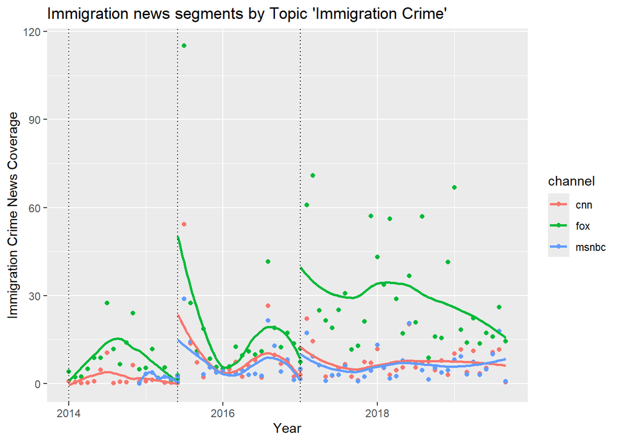

```r
document_topics_figure |>
  group_by(year_month, channel, time) |>
  summarise(topic1_seg = sum((Topic1 +Topic3)*duration )) |>
  ggplot(aes(x = year_month, y = topic1_seg, color = channel, group = interaction(channel, time))) +
  geom_point() + geom_smooth( se=FALSE) +
  geom_vline(data = time_lines, aes(xintercept = as.numeric(year_month)), linetype = "dotted", color = "black") +
  xlab("Year") +
  ylab("Immigration Crime News Coverage") +
  ggtitle("Immigration news segments by Topic 'Immigration Crime'")
```

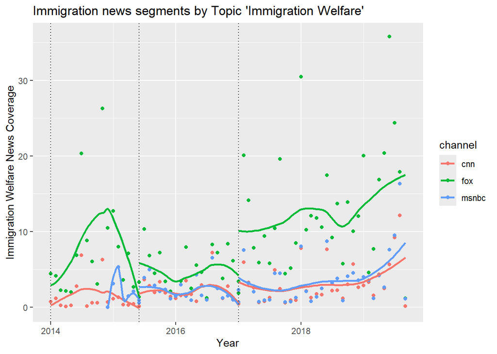

```r
document_topics_figure |>
  group_by(year_month, channel, time) |>
  summarise(topic1_seg = sum((Topic13)*duration )) |>
  ggplot(aes(x = year_month, y = topic1_seg, color = channel, group = interaction(channel, time))) +
  geom_point() + geom_smooth( se=FALSE) +
  geom_vline(data = time_lines, aes(xintercept = as.numeric(year_month)), linetype = "dotted", color = "black") +
  xlab("Year") +
  ylab("Immigration Welfare News Coverage") +
  ggtitle("Immigration news segments by Topic 'Immigration Welfare'")
```

# Table 4 from paper (by month):

```r
head(google_term_data_dummies)
```

```
##          ymd immigr_report immigr_crime immigr_welfare year month president
## 1 2004-01-01             0            0              0 2004     1      bush
## 2 2004-02-01            36            0              0 2004     2      bush
## 3 2004-03-01             0            0              0 2004     3      bush
## 4 2004-04-01            48            0             34 2004     4      bush
## 5 2004-05-01            66            0              0 2004     5      bush
## 6 2004-06-01            35            0              0 2004     6      bush
##   president_obama president_bush president_trump
## 1               0              1               0
## 2               0              1               0
## 3               0              1               0
## 4               0              1               0
## 5               0              1               0
## 6               0              1               0
```

```r
google_term_data_table4 <- google_term_data_dummies|>
  mutate(month= as.factor(month), president_trump= as.factor(president_trump)) |>
  # filter(president_trump == 1) |>
  select(ymd, month, immigr_report, president_trump)

head(google_term_data_table4)
```

```
##          ymd month immigr_report president_trump
## 1 2004-01-01     1             0               0
## 2 2004-02-01     2            36               0
## 3 2004-03-01     3             0               0
## 4 2004-04-01     4            48               0
## 5 2004-05-01     5            66               0
## 6 2004-06-01     6            35               0
```

```r
head(document_topics_figure)
```

```
##          date      Topic1      Topic3     Topic13 year_month channel  duration
##        <Date>       <num>       <num>       <num>     <Date>  <char>     <num>
## 1: 2019-03-31 0.004481022 0.004461316 0.007756699 2019-03-01   msnbc 0.2333333
## 2: 2019-03-31 0.007721907 0.007847635 0.011589109 2019-03-01   msnbc 0.1666667
## 3: 2019-04-01 0.001990162 0.001962287 0.007677318 2019-04-01   msnbc 0.3166667
## 4: 2019-04-01 0.066536793 0.014041768 0.012310378 2019-04-01   msnbc 0.9333333
## 5: 2019-04-01 0.007608635 0.008562301 0.007243552 2019-04-01   msnbc 0.8666667
## 6: 2019-04-01 0.001472374 0.001495451 0.005285978 2019-04-01   msnbc 0.1666667
##             time
##           <fctr>
## 1: post-election
## 2: post-election
## 3: post-election
## 4: post-election
## 5: post-election
## 6: post-election
```

```r
document_topics_table4 <-
  document_topics_figure |>
  mutate(crime = Topic1 + Topic3, welfare = Topic13, ymd = year_month) |>
  # select(crime, welfare, ymd) |>
  group_by(ymd) |>
  summarise(
    segs = n(),
    crime_prop = mean(crime),
    welfare_prop = mean(welfare))

head(document_topics_table4)
```

```
## # A tibble: 6 × 4
##   ymd         segs crime_prop welfare_prop
##   <date>     <int>      <dbl>        <dbl>
## 1 2014-01-01   206     0.0272       0.0267
## 2 2014-02-01   249     0.0181       0.0275
## 3 2014-03-01   112     0.0428       0.0408
## 4 2014-04-01   153     0.0408       0.0206
## 5 2014-05-01   150     0.0857       0.0221
## 6 2014-06-01   613     0.0295       0.0193
```

```r
df_table4_month <- left_join(document_topics_table4, google_term_data_table4, by = "ymd")

head(df_table4_month)
```

```
## # A tibble: 6 × 7
##   ymd         segs crime_prop welfare_prop month immigr_report president_trump
##   <date>     <int>      <dbl>        <dbl> <fct>         <int> <fct>
## 1 2014-01-01   206     0.0272       0.0267 1                44 0
## 2 2014-02-01   249     0.0181       0.0275 2                45 0
## 3 2014-03-01   112     0.0428       0.0408 3                47 0
## 4 2014-04-01   153     0.0408       0.0206 4                41 0
## 5 2014-05-01   150     0.0857       0.0221 5                37 0
## 6 2014-06-01   613     0.0295       0.0193 6                38 0
```

```r
set.seed (1)
model_report_table4_month <- lm(immigr_report ~ (segs  + crime_prop + welfare_prop + president_trump + ymd + month ), data = df_table4_month)
summary(model_report_table4_month)
```

```
##
## Call:
## lm(formula = immigr_report ~ (segs + crime_prop + welfare_prop +
##     president_trump + ymd + month), data = df_table4_month)
##
## Residuals:
##      Min       1Q   Median       3Q      Max
## -17.3864  -3.5776  -0.7535   4.0256  22.5595
##
## Coefficients:
##                    Estimate Std. Error t value Pr(>|t|)
## (Intercept)       93.529389  54.024778   1.731 0.089340 .
## segs               0.009238   0.001929   4.789 1.44e-05 ***
## crime_prop        74.085052  45.179868   1.640 0.107087
## welfare_prop     249.775586 147.552816   1.693 0.096480 .
## president_trump1  16.527402   3.953173   4.181 0.000112 ***
## ymd               -0.003784   0.003284  -1.152 0.254435
## month2             4.031612   4.555194   0.885 0.380200
## month3            -4.143145   4.686286  -0.884 0.380712
## month4            -5.105065   4.663214  -1.095 0.278670
## month5            -7.575348   4.750406  -1.595 0.116846
## month6            -6.248801   4.567795  -1.368 0.177191
## month7            -8.197419   4.675910  -1.753 0.085475 .
## month8           -11.828156   4.596504  -2.573 0.012965 *
## month9            -9.222975   4.800508  -1.921 0.060190 .
## month10          -11.489039   5.078393  -2.262 0.027882 *
## month11           -7.215063   4.851096  -1.487 0.142973
## month12           -5.096368   4.987900  -1.022 0.311631
## ---
## Signif. codes:  0 '***' 0.001 '**' 0.01 '*' 0.05 '.' 0.1 ' ' 1
##
## Residual standard error: 7.787 on 52 degrees of freedom
## Multiple R-squared:  0.7316, Adjusted R-squared:  0.6491
## F-statistic:  8.86 on 16 and 52 DF,  p-value: 7.417e-10
```

```r
stargazer(model_report_table4_month,
          title = "Table 4 OLS",
          dep.var.labels = c("Report"),

          # out = "table4_ols.html", # Save to HTML file
          type = "text", # You can also use "html" or "latex"
          intercept.bottom = FALSE,
          omit.stat = c("ser", "adj.rsq", "f", "aic"),
          notes = "Note: ∗p<0.1; ∗∗p<0.05; ∗∗∗p<0.01" )
```

```
##
## Table 4 OLS
## ==================================================
##                         Dependent variable:
##                  ---------------------------------
##                               Report
## --------------------------------------------------
## Constant                      93.529*
##                              (54.025)
##
## segs                         0.009***
##                               (0.002)
##
## crime_prop                    74.085
##                              (45.180)
##
## welfare_prop                 249.776*
##                              (147.553)
##
## president_trump1             16.527***
##                               (3.953)
##
## ymd                           -0.004
##                               (0.003)
##
## month2                         4.032
##                               (4.555)
##
## month3                        -4.143
##                               (4.686)
##
## month4                        -5.105
##                               (4.663)
##
## month5                        -7.575
##                               (4.750)
##
## month6                        -6.249
##                               (4.568)
##
```

[output cut: 9 more lines]

```
## month10                      -11.489**
##                               (5.078)
##
## month11                       -7.215
##                               (4.851)
##
## month12                       -5.096
##                               (4.988)
##
## --------------------------------------------------
## Observations                    69
## R2                             0.732
## ==================================================
## Note:                  *p<0.1; **p<0.05; ***p<0.01
##                  Note: ∗p<0.1; ∗∗p<0.05; ∗∗∗p<0.01
```

# Table 4 from paper (by day):

```r
daily_report <- read.csv('from_replication_files/gt_report_daily.csv')
head(daily_report)
```

```
##   X       date search search_adj
## 1 1 2004-01-02      0     0.0000
## 2 2 2004-01-03      0     0.0000
## 3 3 2004-01-07     43   102.1889
## 4 4 2004-01-01      0     0.0000
## 5 5 2004-01-06      0     0.0000
## 6 6 2004-01-05      0     0.0000
```

```r
daily_report_table4 <-
  daily_report|>
  mutate( date= as.Date(date), president_trump= ifelse(date< "2017-01-01", 0, 1), president_trump = as.factor(president_trump)) |>
  select(-X)

head(daily_report_table4)
```

```
##         date search search_adj president_trump
## 1 2004-01-02      0     0.0000               0
## 2 2004-01-03      0     0.0000               0
## 3 2004-01-07     43   102.1889               0
## 4 2004-01-01      0     0.0000               0
## 5 2004-01-06      0     0.0000               0
## 6 2004-01-05      0     0.0000               0
```

```r
head(document_topics_figure)
```

```
##          date      Topic1      Topic3     Topic13 year_month channel  duration
##        <Date>       <num>       <num>       <num>     <Date>  <char>     <num>
## 1: 2019-03-31 0.004481022 0.004461316 0.007756699 2019-03-01   msnbc 0.2333333
## 2: 2019-03-31 0.007721907 0.007847635 0.011589109 2019-03-01   msnbc 0.1666667
## 3: 2019-04-01 0.001990162 0.001962287 0.007677318 2019-04-01   msnbc 0.3166667
## 4: 2019-04-01 0.066536793 0.014041768 0.012310378 2019-04-01   msnbc 0.9333333
## 5: 2019-04-01 0.007608635 0.008562301 0.007243552 2019-04-01   msnbc 0.8666667
## 6: 2019-04-01 0.001472374 0.001495451 0.005285978 2019-04-01   msnbc 0.1666667
##             time
##           <fctr>
## 1: post-election
## 2: post-election
## 3: post-election
## 4: post-election
## 5: post-election
## 6: post-election
```

```r
document_topics_table4_day <-
  document_topics_figure |>
  mutate(crime = Topic1 + Topic3, welfare = Topic13) |>
  group_by(date) |>
  summarise(
    segs = n(),
    crime_prop = mean(crime),
    welfare_prop = mean(welfare))

head(document_topics_table4_day)
```

```
## # A tibble: 6 × 4
##   date        segs crime_prop welfare_prop
##   <date>     <int>      <dbl>        <dbl>
## 1 2014-01-01     8    0.00655      0.0131
## 2 2014-01-02     2    0.0338       0.0175
## 3 2014-01-03    10    0.0382       0.119
## 4 2014-01-04     7    0.00866      0.0402
## 5 2014-01-05     2    0.00511      0.00621
## 6 2014-01-07     4    0.00945      0.0141
```

```r
df_table4_day <- left_join(document_topics_table4_day, daily_report_table4, by = "date")

df_table4_day <- df_table4_day |>
  mutate( month = month(date), day_of_week = weekdays(date),
          day_of_week = as.factor(day_of_week), month = as.factor(month))

head(df_table4_day)
```

```
## # A tibble: 6 × 9
##   date        segs crime_prop welfare_prop search search_adj president_trump
##   <date>     <int>      <dbl>        <dbl>  <int>      <dbl> <fct>
## 1 2014-01-01     8    0.00655      0.0131      36       41.2 0
## 2 2014-01-02     2    0.0338       0.0175      36       41.2 0
## 3 2014-01-03    10    0.0382       0.119       14       16.0 0
## 4 2014-01-04     7    0.00866      0.0402      49       56.1 0
## 5 2014-01-05     2    0.00511      0.00621     32       36.6 0
## 6 2014-01-07     4    0.00945      0.0141      27       30.9 0
## # ℹ 2 more variables: month <fct>, day_of_week <fct>
```

```r
set.seed (1)
model_report_table4_day <- lm(search ~ (segs  + crime_prop + welfare_prop + president_trump + date + day_of_week+ month ), data = df_table4_day)
summary(model_report_table4_day)
```

```
##
## Call:
## lm(formula = search ~ (segs + crime_prop + welfare_prop + president_trump +
##     date + day_of_week + month), data = df_table4_day)
##
## Residuals:
##     Min      1Q  Median      3Q     Max
## -47.879 -13.474  -1.382  11.177  61.511
##
## Coefficients:
##                       Estimate Std. Error t value Pr(>|t|)
## (Intercept)          75.806988  23.640469   3.207 0.001364 **
## segs                  0.069327   0.011492   6.033 1.92e-09 ***
## crime_prop           -7.910580   9.225068  -0.858 0.391266
## welfare_prop          2.722003  16.461448   0.165 0.868680
## president_trump1      6.390542   1.697190   3.765 0.000171 ***
## date                 -0.002146   0.001431  -1.500 0.133857
## day_of_weekMonday     1.476294   1.544505   0.956 0.339270
## day_of_weekSaturday  -3.075502   1.547489  -1.987 0.047012 *
## day_of_weekSunday    -5.128327   1.543934  -3.322 0.000911 ***
## day_of_weekThursday   3.129898   1.540661   2.032 0.042333 *
## day_of_weekTuesday   -0.420781   1.540145  -0.273 0.784721
## day_of_weekWednesday  3.990458   1.538551   2.594 0.009565 **
## month2                2.938851   1.990265   1.477 0.139936
## month3               -4.476345   1.988542  -2.251 0.024489 *
## month4                1.549878   1.989376   0.779 0.436026
## month5                1.490120   1.994469   0.747 0.455075
## month6                4.896084   1.986827   2.464 0.013812 *
## month7                4.077213   1.969381   2.070 0.038552 *
## month8                0.218729   1.974354   0.111 0.911798
## month9                0.954531   2.063616   0.463 0.643735
## month10               1.117143   2.103139   0.531 0.595354
## month11               3.736557   2.085526   1.792 0.073338 .
## month12               6.508333   2.110788   3.083 0.002075 **
## ---
## Signif. codes:  0 '***' 0.001 '**' 0.01 '*' 0.05 '.' 0.1 ' ' 1
##
## Residual standard error: 18.56 on 2007 degrees of freedom
##   (5 observations deleted due to missingness)
## Multiple R-squared:  0.08452,    Adjusted R-squared:  0.07448
## F-statistic: 8.422 on 22 and 2007 DF,  p-value: < 2.2e-16
```

```r
stargazer(model_report_table4_day,
          title = "Table 4 OLS (per day)",
          dep.var.labels = c("Report"),

          out = "table4_ols.html", # Save to HTML file
          type = "text", # You can also use "html" or "latex"
          intercept.bottom = FALSE,
          omit.stat = c("ser", "adj.rsq", "f", "aic"),
          notes = "Note: ∗p<0.1; ∗∗p<0.05; ∗∗∗p<0.01" )
```

```
##
## Table 4 OLS (per day)
## ======================================================
##                             Dependent variable:
##                      ---------------------------------
##                                   Report
## ------------------------------------------------------
## Constant                         75.807***
##                                  (23.640)
##
## segs                             0.069***
##                                   (0.011)
##
## crime_prop                        -7.911
##                                   (9.225)
##
## welfare_prop                       2.722
##                                  (16.461)
##
## president_trump1                 6.391***
##                                   (1.697)
##
## date                              -0.002
##                                   (0.001)
##
## day_of_weekMonday                  1.476
##                                   (1.545)
##
## day_of_weekSaturday              -3.076**
##                                   (1.547)
##
## day_of_weekSunday                -5.128***
##                                   (1.544)
##
## day_of_weekThursday               3.130**
##                                   (1.541)
##
## day_of_weekTuesday                -0.421
##                                   (1.540)
##
```

[output cut: 27 more lines]

```
## month10                            1.117
##                                   (2.103)
##
## month11                           3.737*
##                                   (2.086)
##
## month12                          6.508***
##                                   (2.111)
##
## ------------------------------------------------------
## Observations                       2,030
## R2                                 0.085
## ======================================================
## Note:                      *p<0.1; **p<0.05; ***p<0.01
##                      Note: ∗p<0.1; ∗∗p<0.05; ∗∗∗p<0.01
```

# Extension

## The paper shows increase in search of how to report of immigration violation but doesn’t show if there were actual increase in number of reports / arrest/ deportation for immigration violation. For our research question we decided to find out if there was any increase of actual number of reports / arrest/ deportation for immigration violation.

**Data source :** https://www.dhs.gov/ohss/topics/immigration/enforcement-and-legal-processes-monthly-tables

**Data link :** https://onedrive.live.com/edit?id=6779012659AEA485%21120&resid=6779012659AEA485%21120&ithint=file%2Cxlsx&wdPreviousSession=2e2e85d3-ac39-43da-899d-f01ad6e066a7&wdo=2&cid=6779012659aea485

```r
google_term_data_report_extend <-
  google_term_data_dummies |>
  filter(ymd >= '2014-01-01') |>
  rename( year_month = ymd) |>
  select(year_month, year, month, president, immigr_report ) |>
  left_join(time_lines, by = "year_month") |>
  fill(time, .direction = c("down"))

head(google_term_data_report_extend)
```

```
##   year_month year month president immigr_report         time
## 1 2014-01-01 2014     1     obama            44 pre-election
## 2 2014-02-01 2014     2     obama            45 pre-election
## 3 2014-03-01 2014     3     obama            47 pre-election
## 4 2014-04-01 2014     4     obama            41 pre-election
## 5 2014-05-01 2014     5     obama            37 pre-election
## 6 2014-06-01 2014     6     obama            38 pre-election
```

## We will first see what trend the search result of “how to report immigration crime” follows

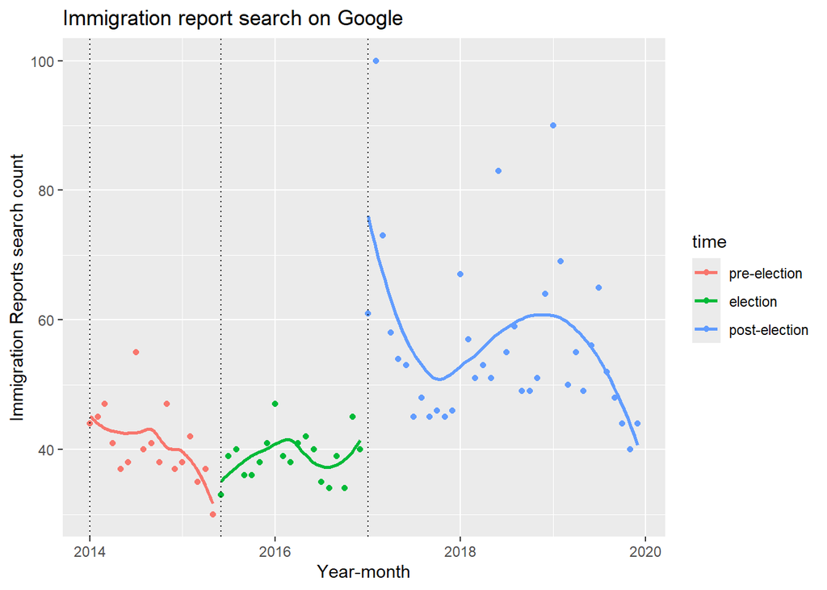

```r
google_term_data_report_extend |>
  ggplot(aes(x = year_month, y = immigr_report, colour = time)) +
  geom_point() + geom_smooth( se=FALSE) +
  geom_vline(data = time_lines, aes(xintercept = as.numeric(year_month)), linetype = "dotted", color = "black") +
  xlab("Year-month") +
  ylab("Immigration Reports search count") +
  ggtitle("Immigration report search on Google")
```

## Now we will see what was the actual number of reporting of “immigration crime” during the given period:

```r
ice <-
  read_csv("extended_research/ice_reportings.csv", skip = 4, col_names = c("year", "month", "reports", "reports_convicted", "", "", "", "reports_non_criminal", "", ""))|>
  select(c(1, 2, 3, 4, 8))|>
  fill(year, .direction = "down")|>
  filter(month != "Total")|>
  mutate(
    month = match(month, month.name),
    date = make_date(year, month)
  )
```

```
## ──────────────────────────────────────────────────────── Delimiter: "," chr
## (2): year, month num (8): reports, reports_convicted, ...5, ...6, ...7,
## reports_non_criminal,...
```

```r
head(ice)
```

```
## # A tibble: 6 × 6
##   year  month reports reports_convicted reports_non_criminal date
##   <chr> <int>   <dbl>             <dbl>                <dbl> <date>
## 1 2014     10   19040             14060                 4980 2014-10-01
## 2 2014     11   16190             11940                 4250 2014-11-01
## 3 2014     12   15710             11630                 4080 2014-12-01
## 4 2014      1   16220             12070                 4150 2014-01-01
## 5 2014      2   15350             11470                 3880 2014-02-01
## 6 2014      3   16310             11780                 4530 2014-03-01
```

```r
ice_report_w_election <-
  ice |>
  filter(date <= '2020-01-01') |>
  rename( year_month = date) |>
  # select(year_month, year, month, president, immigr_report ) |>
  arrange(year_month) |>
  left_join(time_lines, by = "year_month") |>
  fill(time, .direction = c("down"))

head(ice_report_w_election)
```

```
## # A tibble: 6 × 7
##   year  month reports reports_convicted reports_non_criminal year_month time
##   <chr> <int>   <dbl>             <dbl>                <dbl> <date>     <fct>
## 1 2014      1   16220             12070                 4150 2014-01-01 pre-ele…
## 2 2014      2   15350             11470                 3880 2014-02-01 pre-ele…
## 3 2014      3   16310             11780                 4530 2014-03-01 pre-ele…
## 4 2014      4   16530             11880                 4650 2014-04-01 pre-ele…
## 5 2014      5   15120             10960                 4150 2014-05-01 pre-ele…
## 6 2014      6   13870             10100                 3770 2014-06-01 pre-ele…
```

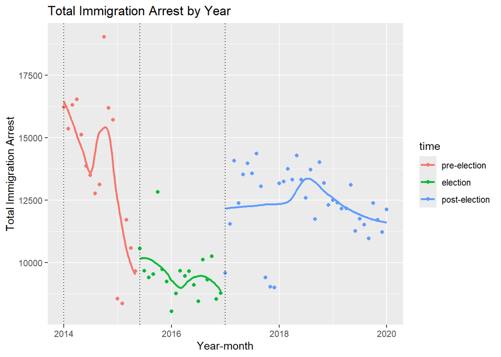

```r
ice_report_w_election|>
  ggplot(aes(x = year_month, y = reports, colour = time)) +
  geom_point() + geom_smooth( se=FALSE) +
  geom_vline(data = time_lines, aes(xintercept = as.numeric(year_month)), linetype = "dotted", color = "black") +

  xlab("Year-month") +

  ylab("Total Immigration Arrest") +

  ggtitle("Total Immigration Arrest by Year")
```

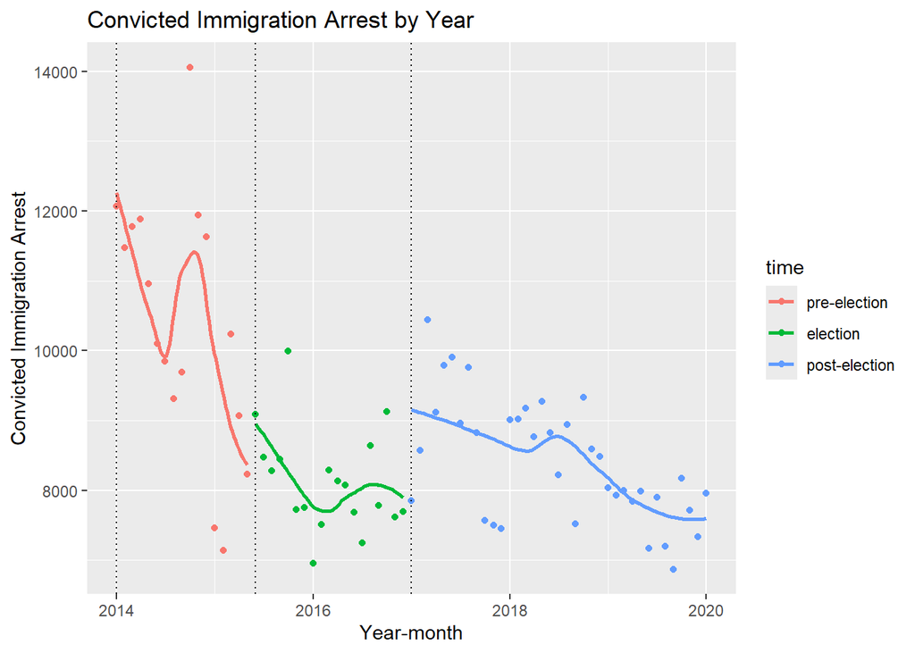

```r
ice_report_w_election|>
  ggplot(aes(x = year_month, y = reports_convicted, colour = time)) +
  geom_point() + geom_smooth( se=FALSE) +
  geom_vline(data = time_lines, aes(xintercept = as.numeric(year_month)), linetype = "dotted", color = "black") +

  xlab("Year-month") +

  ylab("Convicted Immigration Arrest") +

  ggtitle("Convicted Immigration Arrest by Year")
```

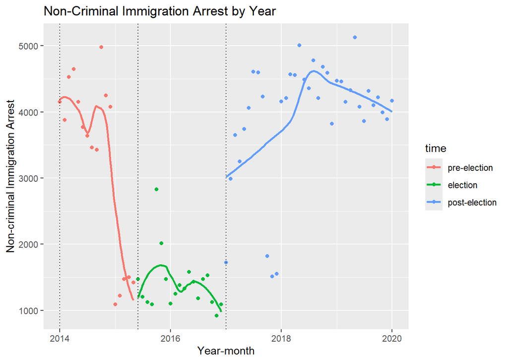

```r
ice_report_w_election|>
  ggplot(aes(x = year_month, y = reports_non_criminal, colour = time)) +
  geom_point() + geom_smooth( se=FALSE) +
  geom_vline(data = time_lines, aes(xintercept = as.numeric(year_month)), linetype = "dotted", color = "black") +

  xlab("Year-month") +

  ylab("Non-criminal Immigration Arrest") +

  ggtitle("Non-Criminal Immigration Arrest by Year")
```

# Paper Findings:

One of the Hypothesis for the paper was ““People will have more interest in reporting immigrants when they believe the government supports deportation.” that means there is more interest in immigrant denunciation when people believe that reporting will lead to some action by the government. In finding the paper suggests that, “Reporting searches (search of”how to report immigrant”) increased sharply after Trump took office and that media reporting on Trump’s immigration policies during his administration (but not during the Trump campaign) is associated with more reporting searches”

# Our Finding:

So for research we decided to look at data from Law enforcement to see if there is a change in number of arrest of immigrants during Trumps period. We used immigrant arrest data from “Office of homeland Security” for our observation.

## Our Process:

We looked into the immigrant arrest data from 3 point of view,

1. Total number of immigrant arrest from January 2014 to December 2019
2. Number of Immigrant arrested for committing crime
3. Number of Immigrant arrested even without committing a crime

## Observation Result

**1) For Total number of arrest & for immigrant arrest for criminal activity:**

- There is higher amounts of arrests pre-campaign (highest),
- a lower number during the campaign (lowest),
- then a spike in numbers post-inauguration but not as high as Pre-campaign (2nd highest)